# Encomran Analysis

Axel Menning

Last compiled on 18 Januar, 2024

Loading required packages

```r
library(knitr)
library(rstatix)
library(readxl)
library(tidyverse)
library(reshape2)
library(ggplot2)
library(ggsignif)
library(forcats)
library(GGally)
library(corrplot)
library(paletteer)
library(fmsb)
library(factoextra)
library(cluster)
library(lsr)
library(multcomp)
library(stats)
library(ggpubr)
library(car)
library(corrplot)
library(Hmisc)
library(likert)
library(janitor)
#library(openxlsx)
```

# Preparation of Raw Data

Load qualtrics export

```r
data_raw <- read_excel("C:/Users/axelm/Desktop/bfr/encomran/Final data text.xlsx")
```

Cleaning and labeling - Filter one participant (ID 2) with no contribution except answering BG1 = RM - Type Both gets only assigned when participants performed RA and RM for the LAST risk analysis

```r
data2 <- data_raw %>%
  slice(-1) %>%
  filter(!(`Intro and Consent`=="No, I do not consent"))%>%
  filter(!(`BG1`=="I don´t know / I prefer not to say."))%>%
  filter(is.na(BLG1)|!(`BLG1`=="I don´t know / I prefer not to say."))%>%
  mutate(ID=row_number(), .before = `Intro and Consent`)%>%
  filter(!(`ID` == "2"))%>%
  mutate(Type=case_when(
         `BG1` == "… only in risk assessment." ~ "RA",
         `BG1` == "… only in risk management." ~ "RM",
         `BLG1` == "… only provide the risk assessment, while the risk management was handled by someone else." ~ "RA",
       `BLG1` == "… only provide the risk management, while the risk assessment was handled by someone else." ~ "RM",
       `BLG1` == "… provide both risk assessment and risk management." ~ "Both"),.before = `Intro and Consent`)%>%
  mutate(org_structure=case_when(
         `BG2a` == "… only provides risk assessment." ~ "fully_separated",
         `BG2a` == "… only provides risk management." ~ "fully_separated",
         `BG2b` == "… by different persons working in different departments." ~ "different_department",
       `BG2b` == "… by different persons within the same department." ~ "same_department",
       `BG2b` == "… by the same person." ~ "same_person"),.before = `Intro and Consent`)%>%
  mutate(did_both=case_when(
         `BG1` == "… only in risk assessment." ~ "RA",
         `BG1` == "… only in risk management." ~ "RM",
         `BG1` == "… only in risk management." ~ "Both"),.before = `Intro and Consent`)%>%
    mutate(sep_nosep=case_when(
         `BG2a` == "… only provides risk assessment." ~ "sep",
         `BG2a` == "… only provides risk management." ~ "sep",
         `BG2b` == "… by different persons working in different departments." ~ "nosep",
         `BG2b` == "… by different persons within the same department." ~ "nosep",
         `BG2b` == "… by the same person." ~ "nosep"),.before = `Intro and Consent`)%>%
    mutate(analysis_cat=case_when(
         `RALG2` == "Routine risk assessment, i.e., a systematic review of all available scientific data to evaluate the magnitude of risks associated with certain hazards." ~ "routine risk analysis",
         `RALG2` == "Expert opinion, i.e., a summary of evidence-based views given by experts in the field (often used when there is a lack of data)." ~ "expert opinion",
         `RALG2` == "Rapid risk assessment, i.e., a risk assessment based on limited data due to time constraints (often used in initial stages of an event or after an incident of potential public health concern)." ~ "rapid risk analysis",
         `RMLG2` == "Routine risk assessment, i.e., a systematic review of all available scientific data to evaluate the magnitude of risks associated with certain hazards." ~ "routine risk analysis",
         `RMLG2` == "Expert opinion, i.e., a summary of evidence-based views given by experts in the field (often used when there is a lack of data)." ~ "expert opinion",
         `RMLG2` == "Rapid risk assessment, i.e., a risk assessment based on limited data due to time constraints (often used in initial stages of an event or after an incident of potential public health concern)." ~ "rapid risk analysis"),.before = `Intro and Consent`)

data2 %>% count(Type)
```

```
## # A tibble: 3 × 2
##   Type      n
##   <chr> <int>
## 1 Both      9
## 2 RA       55
## 3 RM       31
```

```r
data2 %>% count(org_structure)
```

```
## # A tibble: 5 × 2
##   org_structure            n
##   <chr>                <int>
## 1 different_department    37
## 2 fully_separated         48
## 3 same_department          7
## 4 same_person              2
## 5 <NA>                     1
```

```r
data2 %>% count(did_both)
```

```
## # A tibble: 3 × 2
##   did_both     n
##   <chr>    <int>
## 1 RA          47
## 2 RM          21
## 3 <NA>        27
```

```r
data2 %>% count(sep_nosep)
```

```
## # A tibble: 3 × 2
##   sep_nosep     n
##   <chr>     <int>
## 1 nosep        46
## 2 sep          48
## 3 <NA>          1
```

```r
#write.xlsx(data2, '')
```

Filter Type “Both” because they mainly interact with themselves ><.

```r
data <- data2 %>% filter(!(`Type` == "Both"))
```

# Preparation of potential outcome variables

```r
outcome2 <- data2 %>%
  dplyr::select(ID,
                experience = BG4,
                satisfaction = c(RALR2_1, RMLR2_1),
                work_process = c(RALR1_1, RMLR1_1, BLR2_1),
                transparency = c(RALR1_2, RMLR1_2, BLR2_2),
                effectiveness = c(RALR1_3, RMLR1_3, BLR2_3),
                efficiency = c(RALR1_4, RMLR1_4, BLR2_4),
                openness = c(RALR1_5, RMLR1_5, BLR2_5),
                flexibility = c(RALR1_6, RMLR1_6, BLR2_6),
                time_management = c(RALR1_7, RMLR1_7, BLR2_7),
                timeliness = c(RALR1_8, RMLR1_8, BLR2_8),
                familiarity = c(RALR4_1, RMLR4_1),
                vulnerability_a = c(RALR4_2, RMLR4_2),
                vulnerability_b = c(RALR4_3, RMLR4_3),
                vulnerability_c = c(RALR4_4, RMLR4_4),
                feeling_valued = c(RALR4_5, RMLR4_5),
                ability = c(RALR4_6, RMLR4_6),
                interest_alignment = c(RALR4_7, RMLR4_7)) %>%
    mutate(satisfaction = coalesce(satisfaction1, satisfaction2))%>%
  dplyr::select(-satisfaction1, -satisfaction2)%>%
  mutate(satisfaction = gsub("[^0-9.-]", "", satisfaction))%>%
  mutate(satisfaction = as.numeric(satisfaction))%>%
    mutate(work_process = coalesce(work_process1, work_process2, work_process3))%>%
  dplyr::select(-work_process1, -work_process2, -work_process3)%>%
    mutate(transparency = coalesce(transparency1, transparency2, transparency3))%>%
  dplyr::select(-transparency1, -transparency2, -transparency3)%>%
    mutate(effectiveness = coalesce(effectiveness1, effectiveness2, effectiveness3))%>%
  dplyr::select(-effectiveness1, -effectiveness2, -effectiveness3)%>%
    mutate(efficiency = coalesce(efficiency1, efficiency2, efficiency3))%>%
  dplyr::select(-efficiency1, -efficiency2, -efficiency3)%>%
    mutate(openness = coalesce(openness1, openness2, openness3))%>%
  dplyr::select(-openness1, -openness2, -openness3)%>%
    mutate(flexibility = coalesce(flexibility1, flexibility2, flexibility3))%>%
  dplyr::select(-flexibility1, -flexibility2, -flexibility3)%>%
    mutate(time_management = coalesce(time_management1, time_management2, time_management3))%>%
  dplyr::select(-time_management1, -time_management2, -time_management3)%>%
    mutate(timeliness = coalesce(timeliness1, timeliness2, timeliness3))%>%
  dplyr::select(-timeliness1, -timeliness2, -timeliness3)%>%
  mutate(familiarity = coalesce(familiarity1, familiarity2))%>%
  dplyr::select(-familiarity1, -familiarity2)%>%
  mutate(vulnerability_a = coalesce(vulnerability_a1, vulnerability_a2))%>%
  dplyr::select(-vulnerability_a1, -vulnerability_a2)%>%
  mutate(vulnerability_b = coalesce(vulnerability_b1, vulnerability_b2))%>%
  dplyr::select(-vulnerability_b1, -vulnerability_b2)%>%
  mutate(vulnerability_c = coalesce(vulnerability_c1, vulnerability_c2))%>%
  dplyr::select(-vulnerability_c1, -vulnerability_c2)%>%
  mutate(feeling_valued = coalesce(feeling_valued1, feeling_valued2))%>%
  dplyr::select(-feeling_valued1, -feeling_valued2)%>%
  mutate(ability = coalesce(ability1, ability2))%>%
  dplyr::select(-ability1, -ability2)%>%
  mutate(interest_alignment = coalesce(interest_alignment1, interest_alignment2))%>%
  dplyr::select(-interest_alignment1, -interest_alignment2)%>%
  mutate(experience = as.numeric(experience)) %>%
  mutate(experience = ifelse(experience > 60, NA, experience))%>%
  mutate(across(everything(), ~ gsub("[^0-9.-]", "", .)))%>%
  mutate_if(is.character,as.numeric)%>%
  mutate(familiarity = 6 - familiarity)%>%
  mutate(quality = rowMeans(across(work_process:timeliness), na.rm = TRUE))%>%
  mutate(relationship = rowMeans(across(familiarity:interest_alignment), na.rm = TRUE))%>%
  mutate(relationship = replace(relationship, relationship == 0, NA))%>%
  mutate(across(work_process:timeliness, ~ factor(.,
    levels=1:5,
    labels=c('very poor','2','3','4','very good'))))%>%
  mutate(across(familiarity:interest_alignment, ~ factor(.,
    levels=1:5,
    labels=c('do not agree at all','2','3','4','agree completely'))))%>%
  mutate(satisfactionF = factor(satisfaction,
    levels=1:5,
    labels=c('Not at all satisfied','2','3','4','Very satisfied')))

outcome2$Type <- data2$Type
outcome2$org_structure <- data2$org_structure
outcome2$did_both <- data2$did_both
outcome2$sep_nosep <- data2$sep_nosep

sum(complete.cases(outcome2$relationship))
```

```
## [1] 77
```

```r
summary(outcome2$relationship)%>% round(1)
```

```
##    Min. 1st Qu.  Median    Mean 3rd Qu.    Max.    NA's
##     1.0     3.4     4.0     3.9     4.6     5.0      18
```

```r
prop.table(table(outcome2$interest_alignment))%>% `*`(100) %>% round(1)
```

```
##
## do not agree at all                   2                   3                   4
##                 7.9                 7.9                22.2                25.4
##    agree completely
##                36.5
```

```r
tapply(outcome2$experience, outcome2$Type, summary)
```

```
## $Both
##    Min. 1st Qu.  Median    Mean 3rd Qu.    Max.    NA's
##    2.00    8.00   15.00   16.57   25.00   33.00       2
##
## $RA
##    Min. 1st Qu.  Median    Mean 3rd Qu.    Max.    NA's
##    1.00   10.00   15.00   14.91   20.00   40.00       2
##
## $RM
##    Min. 1st Qu.  Median    Mean 3rd Qu.    Max.    NA's
##    0.00    5.00    9.00   11.48   15.00   35.00       2
```

```r
outcome <- outcome2 %>%
  filter(!(`Type` == "Both"))
#write.xlsx(outcome, 'G:/EnComRan/WP_1/Analysis/encomran_outcome.xlsx')
```

# 3C Scoring

1. An empty data frame (Participants X CCC) is created
2. +1`s are dimension-wise assigned, based on 3C rules (McNamara, 2012); text strings are used for a better traceability.
3. sum of scores

```r
scoring <- setNames(data.frame(matrix(ncol = 3, nrow = nrow(data))), c("cooperation", "coordination", "collaboration"))%>%
  mutate(ID= data$ID, .before = `cooperation`)

scoring$Type <- data$Type

scoring[is.na(scoring)] <- 0
```

```r
design <- scoring %>%
  mutate(cooperation = case_when(
    data$BG2a == "… only provides risk assessment." | data$BG2a == "… only provides risk management." ~ 1, TRUE ~ 0))%>%
  mutate(coordination = case_when(
    data$BG3a == "Yes" ~ 1, TRUE ~ 0))%>%
  mutate(collaboration = case_when(
    data$BG2a == "… provides both risk assessment and risk management." ~ 1, TRUE ~ 0))%>%
  mutate(cooperation = case_when(
    coordination == 1 ~ 0, TRUE ~ cooperation))%>%
    mutate(collaboration = case_when(
    coordination == 1 ~ 0, TRUE ~ collaboration))%>%
  mutate(dimension = "design")

#we only keep 9a
# but 9b,c,d,e can be further analyzed, for example to find contradictions.

agreement <- scoring %>%
  mutate(cooperation = case_when(
     (data$RALE9a_1 == "Yes" & data$RALE9a_2 == "No") ~ 1,
     (data$RMLE9a_1 == "Yes" & data$RMLE9a_2 == "No") ~ 1,
     TRUE ~ 0))%>%
  mutate(coordination = case_when(
     (data$RALE9a_1 == "No" & data$RALE9a_2 == "Yes") ~ 1,
     (data$RMLE9a_1 == "No" & data$RMLE9a_2 == "Yes") ~ 1,
     TRUE ~ 0))%>%
  mutate(collaboration = case_when(
     (data$RALE9a_1 == "Yes" & data$RALE9a_2 == "Yes") ~ 1,
     (data$RMLE9a_1 == "Yes" & data$RMLE9a_2 == "Yes") ~ 1,
     TRUE ~ 0))%>%
  mutate(dimension = "formality of agreement")

#agreement <- agreement %>%
  #mutate(cooperation = case_when(
     #data$RALE9b == "The agreements were set by either risk assessment or risk management." ~ cooperation+1,
     #data$RMLE9b == "The agreements were set by either risk assessment or risk management." ~ cooperation+1,
     #TRUE ~ cooperation))%>%
  #mutate(coordination = case_when(
     #data$RALE9b == "The agreements were set by a coordinating entity." ~ coordination+1,
     #data$RMLE9b == "The agreements were set by a coordinating entity." ~ coordination+1,
     #TRUE ~ coordination))%>%
  #mutate(collaboration = case_when(
     #data$RALE9b == "The agreements were set jointly." ~ collaboration+1,
     #data$RMLE9b == "The agreements were set jointly." ~ collaboration+1,
     #TRUE ~ collaboration))%>%
  #mutate(dimension = "formality of agreement")%>%
  #mutate(across(2:4, ~ ./2))

autonomy <- scoring %>%
  mutate(cooperation = case_when(
    data$RALG7 == "The risk assessment was performed fully autonomously." ~ 1,
    data$RMLG7 == "The risk management was performed fully autonomously." ~ 1,
    TRUE ~ 0))%>%
  mutate(coordination = case_when(
    data$RALG7 == "A coordinating entity from another organization coordinated the risk analysis process." | data$RALG7 == "A coordinating entity from my own organization coordinated the risk analysis process." ~ 1,
    data$RMLG7 == "A coordinating entity from another organization coordinated the risk analysis process." | data$RMLG7 == "A coordinating entity from my own organization coordinated the risk analysis process." ~ 1,
    TRUE ~ 0))%>%
  mutate(collaboration = case_when(
    data$RALG7 == "I worked jointly with risk management." ~ 1,
    data$RMLG7 == "I worked jointly with risk assessment." ~ 1,
    TRUE ~ 0))%>%
  mutate(dimension = "organizational autonomy")

personnel <- scoring %>%
  mutate(cooperation = case_when(
    data$RALG6 == "I interacted directly with risk management on a working level, supervisory staff was only involved during approval processes." ~ 1,
    data$RMLG6 == "I interacted directly with risk assessment on a working level, supervisory staff was only involved during approval processes." ~ 1,
    TRUE ~ 0))%>%
  mutate(coordination = case_when(
    data$RALG6 == "A coordinating entity facilitated my interaction with risk management." ~ 1,
    data$RMLG6 == "A coordinating entity facilitated my interaction with risk assessment." ~ 1,
    TRUE ~ 0))%>%
  mutate(collaboration = case_when(
    data$RALG6 == "Me, supervisory staff and potential colleagues interacted on equal footing with risk management." ~ 1,
    data$RMLG6 == "Me, supervisory staff and potential colleagues interacted on equal footing with risk assessment." ~ 1,
    TRUE ~ 0))%>%
  mutate(dimension = "key personnel")

info <- scoring %>%
  mutate(cooperation = case_when(
    (str_detect(data$RALE5, regex("We communicated only if needed", ignore_case = TRUE))) ~ 1,
    (str_detect(data$RMLE5, regex("We communicated only if needed", ignore_case = TRUE))) ~ 1, TRUE ~ 0))%>%
  mutate(coordination=case_when(
    (str_detect(data$RALE5, regex("We had formal proceedings", ignore_case = TRUE))) ~ 1,
    (str_detect(data$RMLE5, regex("We had formal proceedings", ignore_case = TRUE))) ~ 1, TRUE ~ 0))%>%
  mutate(collaboration=case_when(
      (str_detect(data$RALE5, regex("We communicated openly and frequently.", ignore_case = TRUE))) ~ 1,
    (str_detect(data$RMLE5, regex("We communicated openly and frequently.", ignore_case = TRUE))) ~ 1, TRUE ~ 0))%>%
    mutate(cooperation = case_when(
    (cooperation == 1 & coordination == 1) ~ 0, TRUE ~ cooperation))%>%
    mutate(coordination = case_when(
    (coordination == 1 & collaboration == 1) ~ 0, TRUE ~ coordination))%>%
    mutate(cooperation = case_when(
    (cooperation == 1 & collaboration == 1) ~ 0, TRUE ~ cooperation))%>%
  mutate(dimension = "information sharing")

decision <- scoring %>%
  mutate(cooperation = case_when(
    data$RALE1 == "Risk assessment alone." | data$RALE1 == "Risk management alone." ~ 1,
    data$RMLE1 == "Risk assessment alone." | data$RALE1 == "Risk management alone." ~ 1,
    TRUE ~ 0))%>%
  mutate(coordination = case_when(
    data$RALE1 == "A coordinating entity." ~ 1,
    data$RMLE1 == "A coordinating entity." ~ 1,
    TRUE ~ 0))%>%
  mutate(collaboration = case_when(
    data$RALE1 == "Risk assessment and risk management collectively." ~ 1,
    data$RMLE1 == "Risk assessment and risk management collectively." ~ 1,
    TRUE ~ 0))%>%
  mutate(dimension = "decision making")

turf <- scoring %>%
  mutate(cooperation = case_when(
    data$RALE2a == "No" | data$RALE2b == "We did not address the conflicts." ~ 1,
    data$RMLE2a == "No" | data$RMLE2b == "We did not address the conflicts." ~ 1,
    TRUE ~ 0))%>%
  mutate(coordination = case_when(
    (data$RALE2a == "Yes" & data$RALE2b == "We resolved the conflicts with help of a third party.") ~ 1,
    (data$RMLE2a == "Yes" & data$RMLE2b == "We resolved the conflicts with help of a third party.") ~ 1,
    TRUE ~ 0))%>%
  mutate(collaboration = case_when(
    (data$RALE2a == "Yes" & data$RALE2b == "We resolved the conflicts in a team effort without the involvement of a third party.") ~ 1,
    (data$RMLE2a == "Yes" & data$RMLE2b == "We resolved the conflicts in a team effort without the involvement of a third party.") ~ 1,
    TRUE ~ 0))%>%
  mutate(dimension = "turf issues")

resource <- scoring %>%
  mutate(cooperation = case_when(
    data$RALG8a == "No" ~ 1,
    data$RMLG8a == "No" ~ 1,
    TRUE ~ 0))%>%
  mutate(coordination = case_when(
    (data$RALG8a == "Yes" & data$RALG7 == "A coordinating entity from another organization coordinated the risk analysis process.") |
    (data$RALG8a == "Yes" & data$RALG7 == "A coordinating entity from my own organization coordinated the risk analysis process.") |
    (data$RALG8a == "Yes" & data$RALG7 == "The risk management was performed fully autonomously.")
    ~ 1,
    (data$RMLG8a == "Yes" & data$RMLG7 == "A coordinating entity from another organization coordinated the risk analysis process.") |
    (data$RMLG8a == "Yes" & data$RMLG7 == "A coordinating entity from my own organization coordinated the risk analysis process.") |
    (data$RMLG8a == "Yes" & data$RMLG7 == "The risk management was performed fully autonomously.")
    ~ 1, TRUE ~ 0))%>%
  mutate(collaboration = case_when(
    (data$RALG8a == "Yes" & data$RALG7 == "I worked jointly with risk management.") ~ 1,
    (data$RMLG8a == "Yes" & data$RMLG7 == "I worked jointly with risk assessment.") ~ 1,
    TRUE ~ 0))%>%
  mutate(dimension = "resource allocation")

trust <- scoring %>%
  mutate(cooperation = case_when(
    data$RALR5 == "It was not necessary that risk assessors and risk managers trusted each other." ~ 1,
    data$RMLR5 == "It was not necessary that risk assessors and risk managers trusted each other." ~ 1,
    TRUE ~ 0))%>%
  mutate(coordination = case_when(
    data$RALR5 == "Trust was only necessary between supervisory staff of risk assessment and risk management, not on a working level." ~ 1,
    data$RMLR5 == "Trust was only necessary between supervisory staff of risk assessment and risk management, not on a working level." ~ 1,
    TRUE ~ 0))%>%
  mutate(collaboration = case_when(
    data$RALR5 == "It was crucial that all partners trusted each other." ~ 1,
    data$RMLR5 == "It was crucial that all partners trusted each other." ~ 1,
    TRUE ~ 0))%>%
  mutate(dimension = "trust")

system <- scoring %>%
  mutate(cooperation = case_when(
    data$RALE8a == "No" ~ 1,
    data$RMLE8a == "No" ~ 1,
    TRUE ~ 0))%>%
  mutate(coordination = case_when(
    (data$RALE8a == "Yes" & data$RALE8b == "They were only used if they facilitated the risk assessment.") ~ 1,
    (data$RMLE8a == "Yes" & data$RMLE8b == "They were only used if they facilitated the risk management.") ~ 1,
    TRUE ~ 0))%>%
  mutate(collaboration = case_when(
    (data$RALE8a == "Yes" & data$RALE8b == "They are used to facilitate the overall risk analysis process.") ~ 1,
    (data$RMLE8a == "Yes" & data$RMLE8b == "They are used to facilitate the overall risk analysis process.") ~ 1,
    TRUE ~ 0))%>%
  mutate(dimension = "systems thinking")

total <- rbind(design,agreement,autonomy,personnel,info,decision,turf,resource,trust,system)


total_wide <- total %>%
  mutate(ccc = case_when(
    cooperation == 1 ~ 1,
    coordination == 1 ~ 2,
    collaboration == 1 ~ 3,
    TRUE ~ 0)) %>%
  dplyr::select(-c("Type", "cooperation", "coordination", "collaboration"))%>%
  pivot_wider(
    id_cols = ID,
    names_from = dimension,
    values_from = ccc)

#write.xlsx(total_wide, '')
```

# 3C Descriptive results

```r
colSums(total[c("cooperation", "coordination", "collaboration")], na.rm = TRUE)
```

```
##   cooperation  coordination collaboration
##           424           128           193
```

Plotting sums of Risk Analysis Type, Dimensions, Participants; absolute and relative

```r
ccc <- total %>%
  group_by(Type) %>%
  summarise(across(c(cooperation, coordination, collaboration), sum, na.rm = TRUE))
```

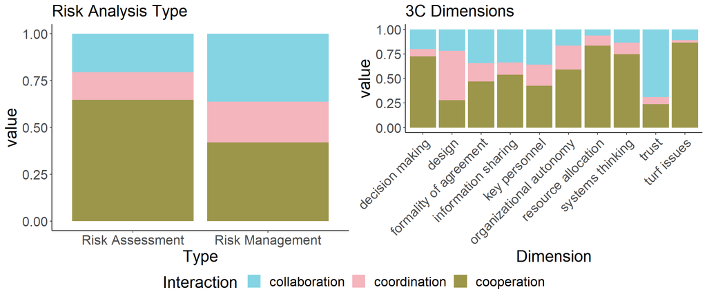

```r
cccplot <- ccc %>%
  pivot_longer(-Type, names_to = "Interaction") %>%
  ggplot(aes(x = Type, y = value, fill = factor(Interaction, levels=c("collaboration","coordination","cooperation")))) +
  scale_x_discrete(labels = c("Risk Assessment", "Risk Management"))+
  geom_col(position="fill") +
  theme_classic()+
  guides(fill=guide_legend(title="Interaction")) +
  scale_fill_paletteer_d("wesanderson::Moonrise3")+
  ggtitle("Risk Analysis Type")+
  theme(
        text = element_text(size=20),
        plot.title = element_text(size = 20))

dims <- total %>%
  group_by(dimension) %>%
  summarise(across(c(cooperation, coordination, collaboration), sum, na.rm = TRUE)) %>%
  pivot_longer(-dimension, names_to = "Interaction")

dimsplot <- ggplot(dims, aes(x = dimension, y = value, fill = factor(Interaction, levels=c("collaboration","coordination","cooperation")))) +
  geom_col(position="fill") +
  guides(fill=guide_legend(title="Interaction")) +
  theme_classic()+
  theme(axis.text.x=element_text(angle=45,hjust=1),
        text = element_text(size=20),
        plot.title = element_text(size = 20)) +
  scale_fill_paletteer_d("wesanderson::Moonrise3") +
  ggtitle("3C Dimensions")+
  xlab("Dimension")
ggarrange(cccplot, dimsplot, ncol=2, nrow=1, common.legend = TRUE, legend="bottom")
```

# 3C Variance Analysis

[figure not shown]

```r
individual <- total %>%
  group_by(ID) %>%
  summarise(across(c(cooperation, coordination, collaboration), sum, na.rm = TRUE))

corrdf <- cbind(individual, Type = scoring$Type)
corrdf$Type <- as.factor(corrdf$Type)
corrdf$ID <- NULL

desired_order <- c("collaboration", "coordination", "cooperation")

plot_difference <- corrdf %>%
  mutate(Type = factor(Type , levels=c("RA","RM"))) %>%
  pivot_longer(cols = -Type) %>%
  mutate(name = factor(name, levels = desired_order)) %>%
  ggplot(aes(x = Type, y = value, fill = name)) +
  geom_boxplot() +
  scale_x_discrete(labels = c("Risk Assessment", "Risk Management"))+
  guides(fill = guide_legend(title = "Interaction"))+
  ylab("Interaction score")+
  scale_fill_paletteer_d("wesanderson::Moonrise3") +
  labs(subtitle = "MANOVA, F(3,82) = 9.95")+
  geom_signif(
    annotation = "***",
    textsize = 8,
    y_position = 11, xmin = 0.75, xmax = 1.75,
    tip_length = 0
  )+
  geom_signif(
    annotation = "NS",
    textsize = 5,
    y_position = 12.2, xmin = 1, xmax = 2,
    tip_length = 0
  )+
  geom_signif(
    annotation = "***",
    textsize = 8,
    y_position = 13.4, xmin = 1.25, xmax = 2.25,
    tip_length = 0
  )+
  theme_classic()+
  theme(text = element_text(size=20),
        plot.title = element_text(size = 20))

plot_difference
```

```r
model <- lm(cbind(cooperation, coordination, collaboration) ~ Type, data = corrdf)
Manova(model, test.statistic = "Pillai")
```

```
##
## Type II MANOVA Tests: Pillai test statistic
##      Df test stat approx F num Df den Df    Pr(>F)
## Type  1    0.2668   9.9459      3     82 1.158e-05 ***
## ---
## Signif. codes:  0 '***' 0.001 '**' 0.01 '*' 0.05 '.' 0.1 ' ' 1
```

```r
summary.aov(model)
```

```
##  Response cooperation :
##             Df Sum Sq Mean Sq F value    Pr(>F)
## Type         1 101.40 101.403  27.285 1.255e-06 ***
## Residuals   84 312.18   3.716
## ---
## Signif. codes:  0 '***' 0.001 '**' 0.01 '*' 0.05 '.' 0.1 ' ' 1
##
##  Response coordination :
##             Df  Sum Sq Mean Sq F value  Pr(>F)
## Type         1   4.904  4.9042  3.0609 0.08385 .
## Residuals   84 134.584  1.6022
## ---
## Signif. codes:  0 '***' 0.001 '**' 0.01 '*' 0.05 '.' 0.1 ' ' 1
##
##  Response collaboration :
##             Df Sum Sq Mean Sq F value    Pr(>F)
## Type         1  27.69 27.6903  12.767 0.0005873 ***
## Residuals   84 182.18  2.1688
## ---
## Signif. codes:  0 '***' 0.001 '**' 0.01 '*' 0.05 '.' 0.1 ' ' 1
```

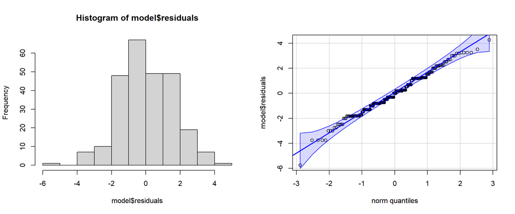

```r
# check for normality
par(mfrow = c(1, 2))
hist(model$residuals)
car::qqPlot(model$residuals,id = FALSE)
```

```r
shapiro.test(model$residuals)
```

```
##
##  Shapiro-Wilk normality test
##
## data:  model$residuals
## W = 0.98895, p-value = 0.04603
```

```r
# check for homogenity; p > .05 indicates homogenity of error variance is true
car::leveneTest(cooperation ~ Type, data = corrdf, as.na = TRUE)
```

```
## Levene's Test for Homogeneity of Variance (center = median: TRUE)
##       Df F value Pr(>F)
## group  1  0.7205 0.3984
##       84
```

```r
car::leveneTest(coordination ~ Type, data = corrdf, as.na = TRUE)
```

```
## Levene's Test for Homogeneity of Variance (center = median: TRUE)
##       Df F value Pr(>F)
## group  1  2.6545  0.107
##       84
```

```r
car::leveneTest(collaboration ~ Type, data = corrdf, as.na = TRUE)
```

```
## Levene's Test for Homogeneity of Variance (center = median: TRUE)
##       Df F value  Pr(>F)
## group  1  3.6704 0.05879 .
##       84
## ---
## Signif. codes:  0 '***' 0.001 '**' 0.01 '*' 0.05 '.' 0.1 ' ' 1
```

# differences in interaction for rapid risk analysis

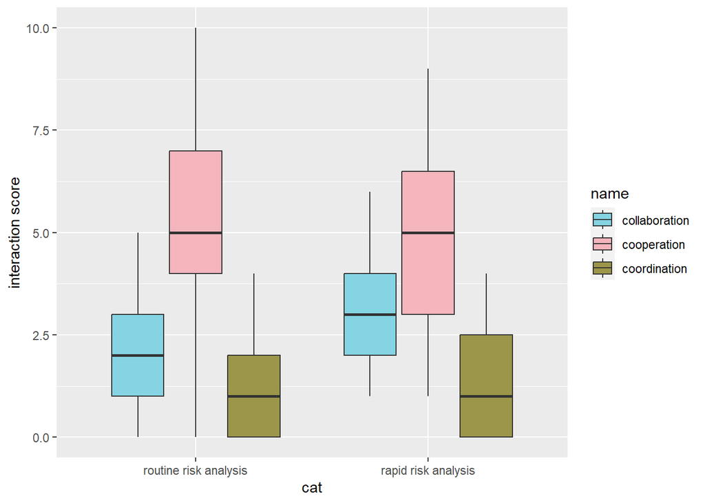

```r
individual <- total %>%
  group_by(ID) %>%
  summarise(across(c(cooperation, coordination, collaboration), sum, na.rm = TRUE))

corrdf <- cbind(individual, cat = data$analysis_cat)
corrdf$cat <- as.factor(corrdf$cat)
corrdf$ID <- NULL
corrdf <- corrdf[!is.na(corrdf$cat), ]
corrdf <- corrdf[!apply(corrdf == "expert opinion", 1, any), ]

plot_difference <- corrdf %>%
  mutate(cat = factor(cat, levels=c("routine risk analysis","rapid risk analysis"))) %>%
  pivot_longer(cols = -cat) %>%
  ggplot(aes(x = cat, y = value, fill = name)) +
  geom_boxplot() +
  scale_fill_paletteer_d("wesanderson::Moonrise3")+
  ylab("interaction score")

plot_difference
```

```r
model <- lm(cbind(cooperation, coordination, collaboration) ~ cat, data = corrdf)
Manova(model, test.statistic = "Pillai")
```

```
##
## Type II MANOVA Tests: Pillai test statistic
##     Df test stat approx F num Df den Df Pr(>F)
## cat  1   0.14683   3.3846      3     59 0.0239 *
## ---
## Signif. codes:  0 '***' 0.001 '**' 0.01 '*' 0.05 '.' 0.1 ' ' 1
```

```r
summary.aov(model)
```

```
##  Response cooperation :
##             Df Sum Sq Mean Sq F value Pr(>F)
## cat          1   6.61  6.6108  1.2524 0.2675
## Residuals   61 321.99  5.2786
##
##  Response coordination :
##             Df Sum Sq Mean Sq F value Pr(>F)
## cat          1  0.889 0.88904   0.555 0.4591
## Residuals   61 97.714 1.60187
##
##  Response collaboration :
##             Df  Sum Sq Mean Sq F value   Pr(>F)
## cat          1  19.532 19.5324  8.0857 0.006063 **
## Residuals   61 147.357  2.4157
## ---
## Signif. codes:  0 '***' 0.001 '**' 0.01 '*' 0.05 '.' 0.1 ' ' 1
```

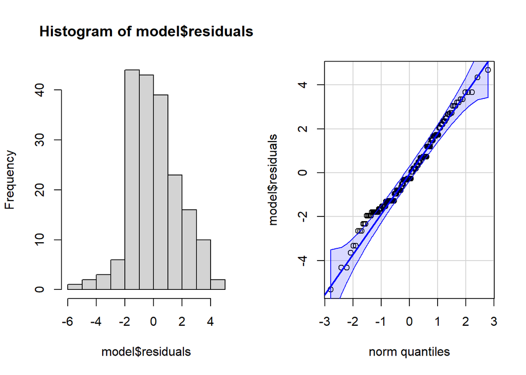

```r
# check for normality
par(mfrow = c(1, 2))
hist(model$residuals)
car::qqPlot(model$residuals,id = FALSE)
```

```r
shapiro.test(model$residuals)
```

```
##
##  Shapiro-Wilk normality test
##
## data:  model$residuals
## W = 0.98542, p-value = 0.0475
```

```r
# check for homogenity; p > .05 indicates homogenity of error variance is true
car::leveneTest(cooperation ~ cat, data = corrdf, as.na = TRUE)
```

```
## Levene's Test for Homogeneity of Variance (center = median: TRUE)
##       Df F value Pr(>F)
## group  1  0.0184 0.8925
##       61
```

```r
car::leveneTest(coordination ~ cat, data = corrdf, as.na = TRUE)
```

```
## Levene's Test for Homogeneity of Variance (center = median: TRUE)
##       Df F value Pr(>F)
## group  1  0.5437 0.4637
##       61
```

```r
car::leveneTest(collaboration ~ cat, data = corrdf, as.na = TRUE)
```

```
## Levene's Test for Homogeneity of Variance (center = median: TRUE)
##       Df F value Pr(>F)
## group  1  0.3923 0.5334
##       61
```

# K means clustering of 3C scores

Cluster participants into groups based on 3c answers

Find optimal number of clusters

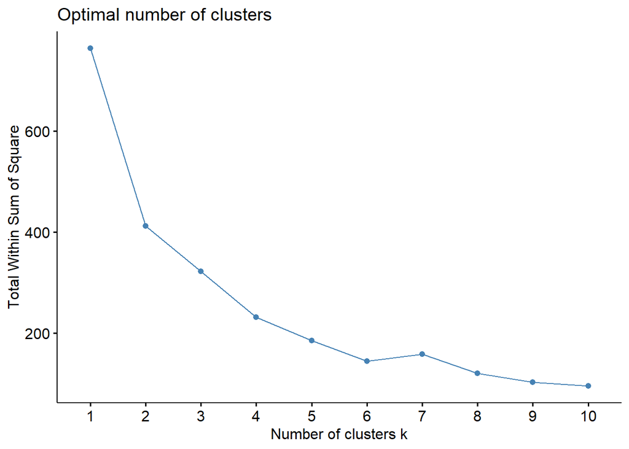

```r
km_df <- individual
km_df$ID <- NULL

fviz_nbclust(km_df, kmeans, method = "wss")
```

```r
#alternative methode
#gap_stat <- clusGap(km_df,FUN = kmeans,nstart = 25,K.max = 10,B = 50)
#fviz_gap_stat(gap_stat)
```

```r
set.seed(1)
km <- kmeans(km_df, centers = 7, iter.max = 800)
km
```

```
## K-means clustering with 7 clusters of sizes 16, 12, 5, 12, 19, 10, 12
##
## Cluster means:
##   cooperation coordination collaboration
## 1    2.125000     3.000000     2.1250000
## 2    7.416667     0.500000     1.2500000
## 3    9.200000     0.200000     0.4000000
## 4    5.833333     2.416667     0.5833333
## 5    5.157895     1.473684     2.6842105
## 6    5.300000     0.000000     2.4000000
## 7    2.833333     1.333333     5.0000000
##
## Clustering vector:
##  [1] 2 2 1 5 1 6 4 7 1 1 2 7 6 6 6 2 7 4 1 1 2 5 7 5 3 4 3 4 2 7 5 3 5 4 5 5 6 1
## [39] 2 7 4 7 5 6 4 7 5 2 1 1 1 4 5 4 1 3 6 2 5 5 1 1 5 7 1 7 5 1 5 3 2 1 2 6 5 4
## [77] 4 5 4 7 5 2 7 5 6 6
##
## Within cluster sum of squares by cluster:
## [1] 67.50000 10.16667  2.80000 19.50000 21.36842  8.50000 30.33333
##  (between_SS / total_SS =  79.0 %)
##
## Available components:
##
## [1] "cluster"      "centers"      "totss"        "withinss"     "tot.withinss"
## [6] "betweenss"    "size"         "iter"         "ifault"
```

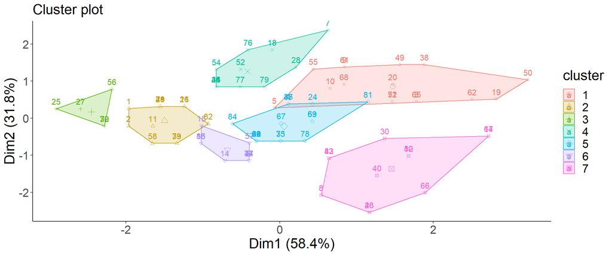

```r
fviz_cluster(km, data = km_df)+
  theme_classic()+
  theme(text = element_text(size=20),
        plot.title = element_text(size = 20))
```

```r
km_df_scaled <- scale(km_df)

set.seed(12)
kmeans_result <- kmeans(km_df_scaled, centers = 3)
kmeans_result
```

```
## K-means clustering with 3 clusters of sizes 22, 35, 29
##
## Cluster means:
##   cooperation coordination collaboration
## 1  -1.0605209    1.2864575    0.01816372
## 2   0.8217445   -0.4258407   -0.73725473
## 3  -0.1872275   -0.4619877    0.87601082
##
## Clustering vector:
##  [1] 2 2 1 2 2 3 1 3 1 1 2 3 2 3 2 2 1 1 1 1 2 3 3 1 2 2 2 1 2 3 3 2 3 2 2 3 3 1
## [39] 2 3 2 3 3 3 2 3 2 2 1 1 1 2 3 2 1 2 3 2 3 3 1 1 3 1 1 3 3 1 3 2 2 1 2 3 3 2
## [77] 2 3 2 3 1 2 3 2 2 2
##
## Within cluster sum of squares by cluster:
## [1] 38.17973 45.26245 31.93188
##  (between_SS / total_SS =  54.8 %)
##
## Available components:
##
## [1] "cluster"      "centers"      "totss"        "withinss"     "tot.withinss"
## [6] "betweenss"    "size"         "iter"         "ifault"
```

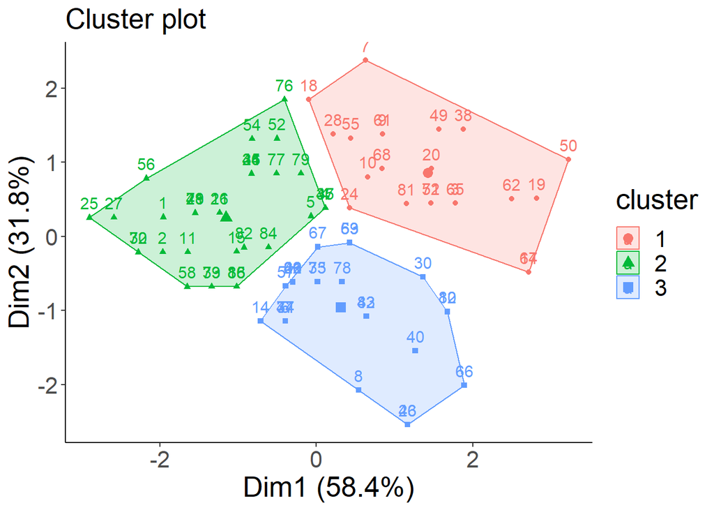

```r
fviz_cluster(kmeans_result, data = km_df_scaled)+
  theme_classic()+
  theme(text = element_text(size=20),
        plot.title = element_text(size = 20))
```

Compare 3 cluster against quality

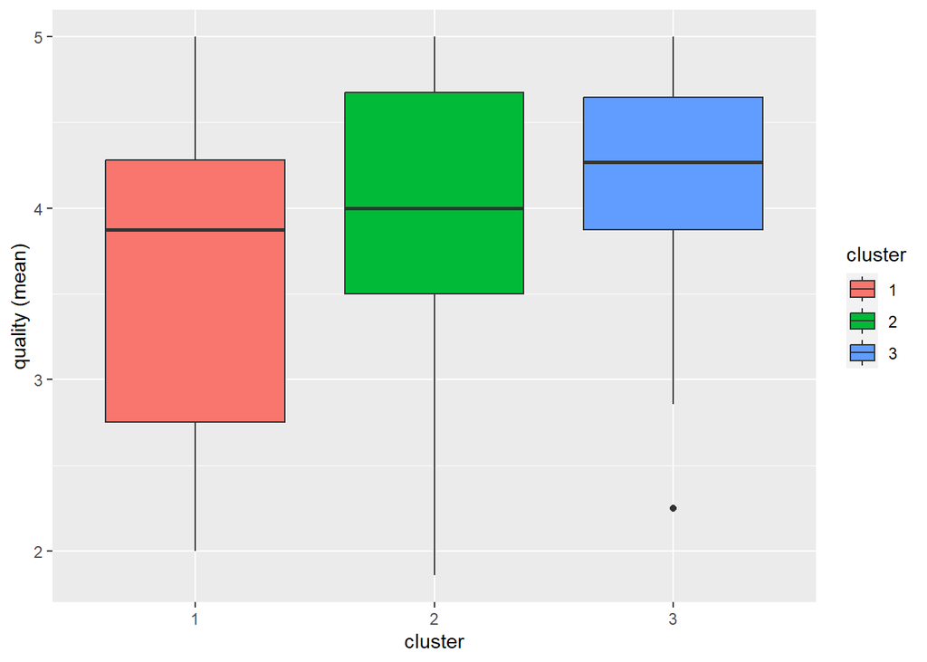

```r
outcome_ccccluster <- outcome %>%
  cbind(data.frame(cluster = kmeans_result[["cluster"]]))%>%
  relocate(cluster, .after = ID) %>%
  mutate(cluster = factor(cluster, levels=c("1","2","3")))


ggplot(outcome_ccccluster, aes(x = cluster, y = quality, fill = cluster)) +
  geom_boxplot()+
  ylab("quality (mean)")
```

```r
kruskal.test(outcome_ccccluster$quality~outcome_ccccluster$cluster)
```

```
##
##  Kruskal-Wallis rank sum test
##
## data:  outcome_ccccluster$quality by outcome_ccccluster$cluster
## Kruskal-Wallis chi-squared = 3.418, df = 2, p-value = 0.181
```

```r
outcome_ccccluster <- outcome %>%
  cbind(data.frame(cluster = km[["cluster"]]))%>%
  relocate(cluster, .after = ID) %>%
  mutate(cluster = factor(cluster, levels=as.character(1:7)))
```

7 cluster ~ experience & satisfaction

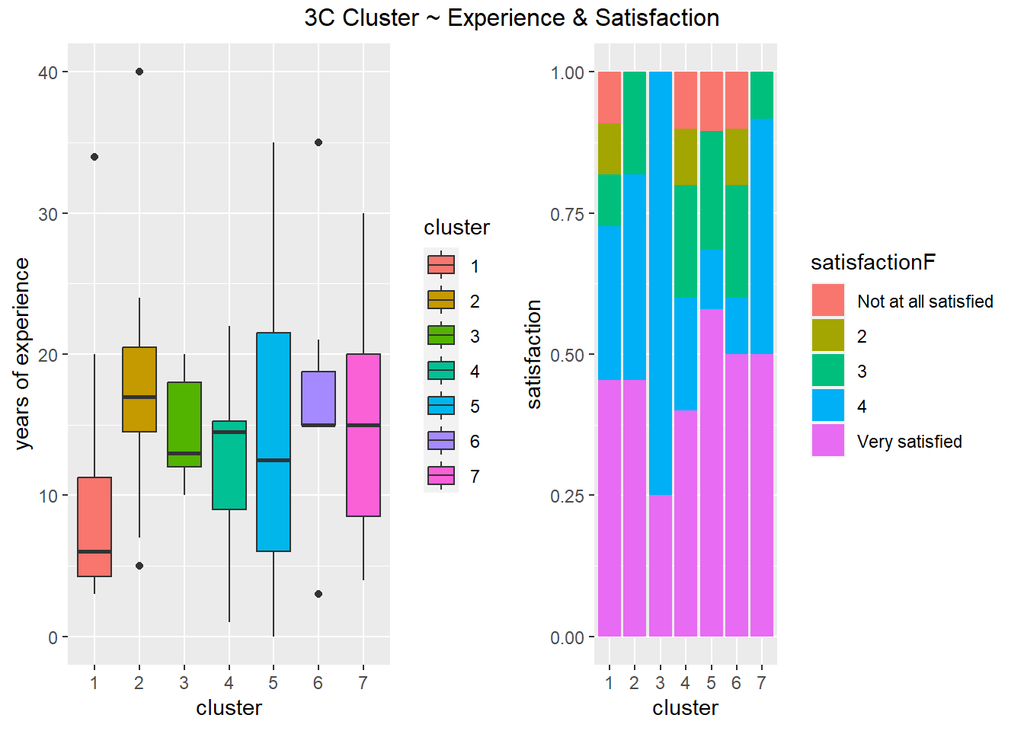

```r
plot_exp <- ggplot(outcome_ccccluster, aes(x = cluster, y = experience, fill = cluster)) +
  geom_boxplot() +
  ylab("years of experience")

plot_satis <- ggplot(data=subset(outcome_ccccluster, !is.na(satisfactionF)), aes(x = cluster)) +
  geom_bar(aes(fill=satisfactionF), position="fill")+
  ylab("satisfaction")

plot_o3 <- ggarrange(plot_exp, plot_satis, ncol=2, nrow=1, common.legend = FALSE)
annotate_figure(plot_o3, top = text_grob("3C Cluster ~ Experience & Satisfaction", size = 12))
```

```r
#Tests
aov_exp_c <- aov(experience ~ cluster, data = outcome_ccccluster)
summary(aov_exp_c)
```

```
##             Df Sum Sq Mean Sq F value Pr(>F)
## cluster      6    553   92.13   1.242  0.295
## Residuals   75   5565   74.19
## 4 observations deleted due to missingness
```

```r
kruskal.test(outcome_ccccluster$satisfaction~outcome_ccccluster$cluster)
```

```
##
##  Kruskal-Wallis rank sum test
##
## data:  outcome_ccccluster$satisfaction by outcome_ccccluster$cluster
## Kruskal-Wallis chi-squared = 1.6382, df = 6, p-value = 0.9498
```

7 cluster ~ perceived quality

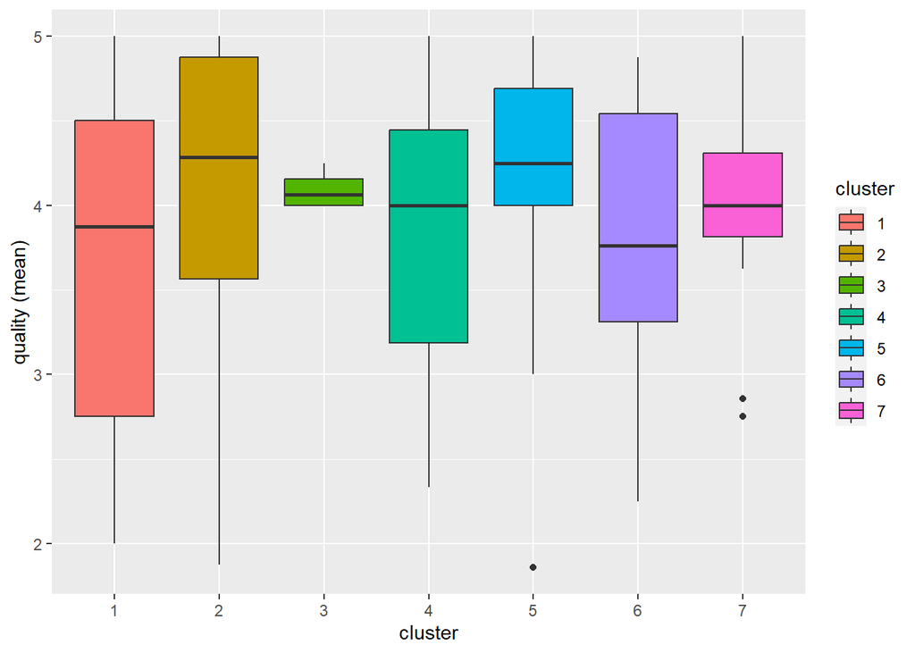

```r
ggplot(outcome_ccccluster, aes(x = cluster, y = quality, fill = cluster)) +
  geom_boxplot()+
  ylab("quality (mean)")
```

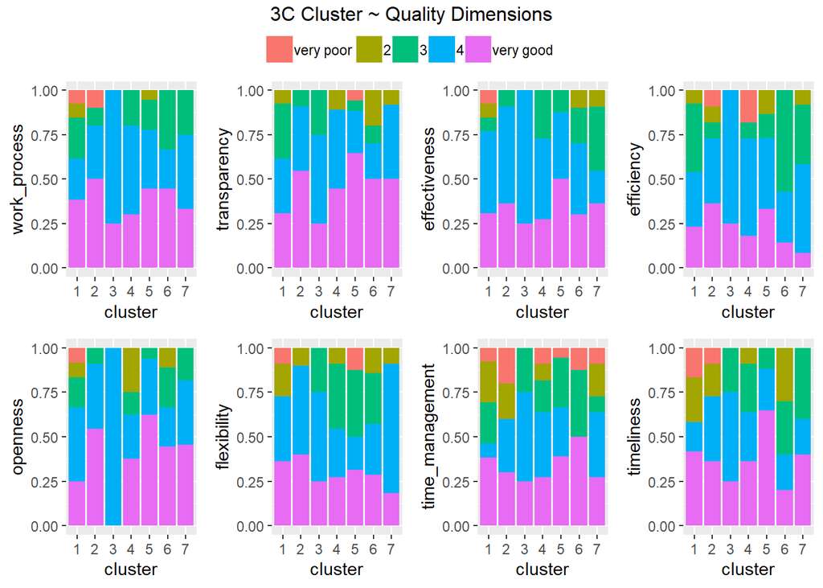

```r
plot_q1 <- ggplot(data=subset(outcome_ccccluster, !is.na(work_process)), aes(x = cluster))+
  geom_bar(aes(fill = work_process), position="fill")+
  ylab("work_process")+
  theme(legend.title = element_text(size = 0))

plot_q2 <- ggplot(data=subset(outcome_ccccluster, !is.na(transparency)), aes(x = cluster)) +
  geom_bar(aes(fill = transparency), position="fill")+
  ylab("transparency")

plot_q3 <- ggplot(data=subset(outcome_ccccluster, !is.na(effectiveness)), aes(x = cluster)) +
  geom_bar(aes(fill = effectiveness), position="fill")+
  ylab("effectiveness")

plot_q4 <- ggplot(data=subset(outcome_ccccluster, !is.na(efficiency)), aes(x = cluster)) +
  geom_bar(aes(fill = efficiency), position="fill")+
  ylab("efficiency")

plot_q5 <- ggplot(data=subset(outcome_ccccluster, !is.na(openness)), aes(x = cluster)) +
  geom_bar(aes(fill = openness), position="fill")+
  ylab("openness")

plot_q6 <- ggplot(data=subset(outcome_ccccluster, !is.na(flexibility)), aes(x = cluster)) +
  geom_bar(aes(fill = flexibility), position="fill")+
  ylab("flexibility")

plot_q7 <- ggplot(data=subset(outcome_ccccluster, !is.na(time_management)), aes(x = cluster)) +
  geom_bar(aes(fill = time_management), position="fill")+
  ylab("time_management")

plot_q8 <- ggplot(data=subset(outcome_ccccluster, !is.na(timeliness)), aes(x = cluster)) +
  geom_bar(aes(fill = timeliness), position="fill")+
  ylab("timeliness")

plot_o4 <- ggarrange(plot_q1,plot_q2,plot_q3,plot_q4,plot_q5,plot_q6,plot_q7,plot_q8, ncol=4, nrow=2, common.legend = TRUE)

annotate_figure(plot_o4, top = text_grob("3C Cluster ~ Quality Dimensions", size = 12))
```

```r
#Kruskall-Wallis test
cols <- names(outcome_ccccluster)[5:12]
KWTcluster <- lapply(cols, function(x)
  kruskal.test(reformulate("cluster", x), data = outcome_ccccluster))

KWTcluster <- lapply(KWTcluster, "[", c("data.name", "p.value"))

kable(t(as.data.frame(KWTcluster)))
```

| data.name | work_process by cluster |
| --- | --- |
| p.value | 0.9834887 |
| data.name.1 | transparency by cluster |
| p.value.1 | 0.5176963 |
| data.name.2 | effectiveness by cluster |
| p.value.2 | 0.7217168 |
| data.name.3 | efficiency by cluster |
| p.value.3 | 0.726942 |
| data.name.4 | openness by cluster |
| p.value.4 | 0.2653723 |
| data.name.5 | flexibility by cluster |
| p.value.5 | 0.8676747 |
| data.name.6 | time_management by cluster |
| p.value.6 | 0.9556232 |
| data.name.7 | timeliness by cluster |
| p.value.7 | 0.1998812 |

# 3C cluster - relationship

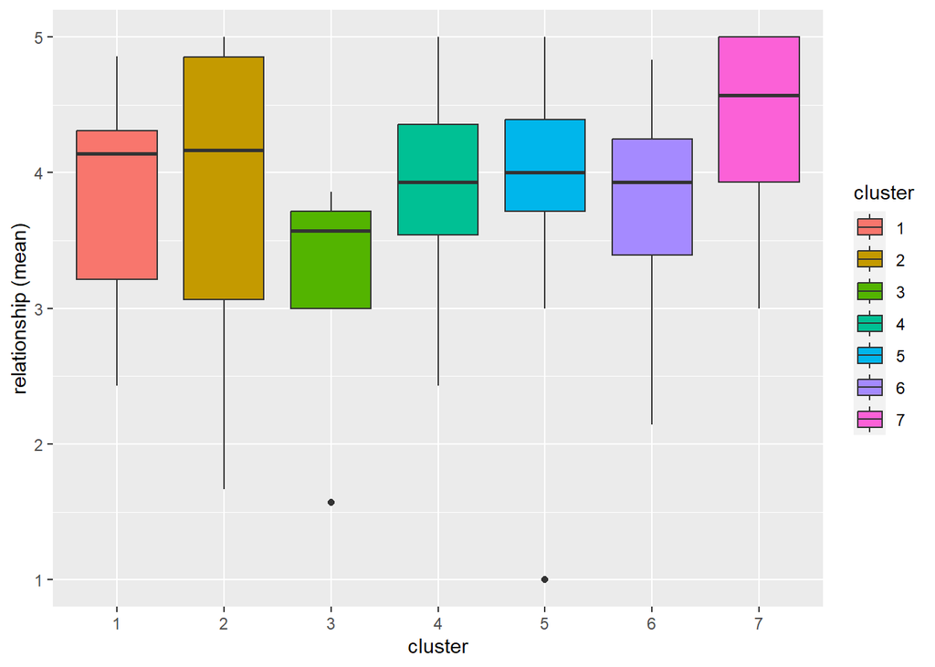

```r
ggplot(outcome_ccccluster, aes(x = cluster, y = relationship, fill = cluster)) +
  geom_boxplot()+
  ylab("relationship (mean)")
```

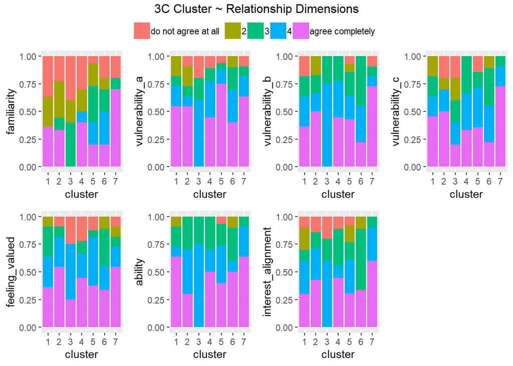

```r
plot_r1 <- ggplot(data=subset(outcome_ccccluster, !is.na(familiarity)), aes(x = cluster)) +
  geom_bar(aes(fill = familiarity), position="fill")+
  ylab("familiarity")+
  theme(legend.title = element_text(size = 0))

plot_r2 <- ggplot(data=subset(outcome_ccccluster, !is.na(vulnerability_a)), aes(x = cluster)) +
  geom_bar(aes(fill = vulnerability_a), position="fill")+
  ylab("vulnerability_a")

plot_r3 <- ggplot(data=subset(outcome_ccccluster, !is.na(vulnerability_b)), aes(x = cluster)) +
  geom_bar(aes(fill = vulnerability_b), position="fill")+
  ylab("vulnerability_b")

plot_r4 <- ggplot(data=subset(outcome_ccccluster, !is.na(vulnerability_c)), aes(x = cluster)) +
  geom_bar(aes(fill = vulnerability_c), position="fill")+
  ylab("vulnerability_c")

plot_r5 <- ggplot(data=subset(outcome_ccccluster, !is.na(feeling_valued)), aes(x = cluster)) +
  geom_bar(aes(fill = feeling_valued), position="fill")+
  ylab("feeling_valued")

plot_r6 <- ggplot(data=subset(outcome_ccccluster, !is.na(ability)), aes(x = cluster)) +
  geom_bar(aes(fill = ability), position="fill")+
  ylab("ability")

plot_r7 <- ggplot(data=subset(outcome_ccccluster, !is.na(interest_alignment)), aes(x = cluster)) +
  geom_bar(aes(fill = interest_alignment), position="fill")+
  ylab("interest_alignment")

plot_qual_all <- ggarrange(plot_r1,plot_r2,plot_r3,plot_r4,plot_r5,plot_r6,plot_r7, ncol=4, nrow=2, common.legend = TRUE)

annotate_figure(plot_qual_all, top = text_grob("3C Cluster ~ Relationship Dimensions", size = 12))
```

```r
#Kruskall-Wallis test
cols <- names(outcome_ccccluster)[13:19]
KWTcluster <- lapply(cols, function(x)
  kruskal.test(reformulate("cluster", x), data = outcome_ccccluster))

KWTcluster <- lapply(KWTcluster, "[", c("data.name", "p.value"))

kable(t(as.data.frame(KWTcluster)))
```

| data.name | familiarity by cluster |
| --- | --- |
| p.value | 0.3858402 |
| data.name.1 | vulnerability_a by cluster |
| p.value.1 | 0.251877 |
| data.name.2 | vulnerability_b by cluster |
| p.value.2 | 0.5645149 |
| data.name.3 | vulnerability_c by cluster |
| p.value.3 | 0.2844027 |
| data.name.4 | feeling_valued by cluster |
| p.value.4 | 0.9319618 |
| data.name.5 | ability by cluster |
| p.value.5 | 0.6031327 |
| data.name.6 | interest_alignment by cluster |
| p.value.6 | 0.4342255 |

# Type ~ Experience & Satisfaction

“How satisfied were you overall with the communication between you and the risk manager/risk assessment during the last risk analysis?”

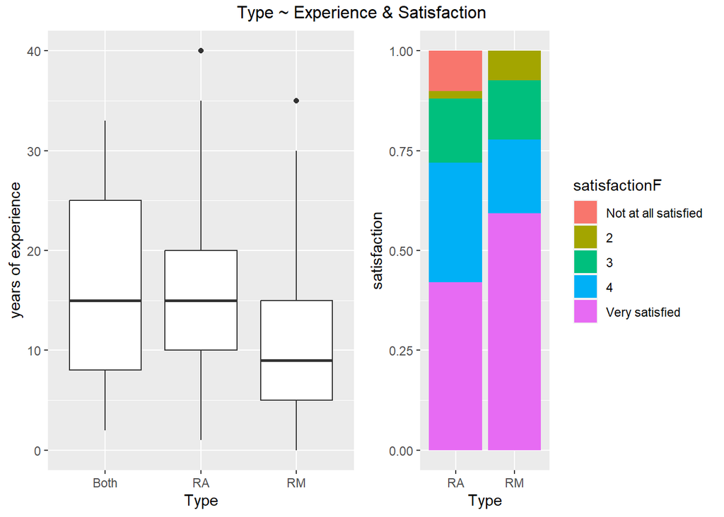

```r
exp_type_plot <- ggplot(outcome2, aes(x = Type, y = experience)) +
  geom_boxplot()+
  ylab("years of experience")

satis_type_plot <-  ggplot(data=subset(outcome, !is.na(satisfactionF)), aes(x = Type)) +
  geom_bar(aes(fill=satisfactionF), position="fill")+
  ylab("satisfaction")

plot_o1 <- ggarrange(exp_type_plot, satis_type_plot, ncol=2, nrow=1, common.legend = FALSE)
annotate_figure(plot_o1, top = text_grob("Type ~ Experience & Satisfaction", size = 12))
```

```r
# Tests
aov_exp <- aov(experience ~ Type, data = outcome)
summary(aov_exp)
```

```
##             Df Sum Sq Mean Sq F value Pr(>F)
## Type         1    220  219.61   2.979 0.0882 .
## Residuals   80   5898   73.72
## ---
## Signif. codes:  0 '***' 0.001 '**' 0.01 '*' 0.05 '.' 0.1 ' ' 1
## 4 observations deleted due to missingness
```

```r
kruskal.test(outcome_ccccluster$satisfaction~outcome_ccccluster$Type)
```

```
##
##  Kruskal-Wallis rank sum test
##
## data:  outcome_ccccluster$satisfaction by outcome_ccccluster$Type
## Kruskal-Wallis chi-squared = 1.7523, df = 1, p-value = 0.1856
```

# Quality ~ Type

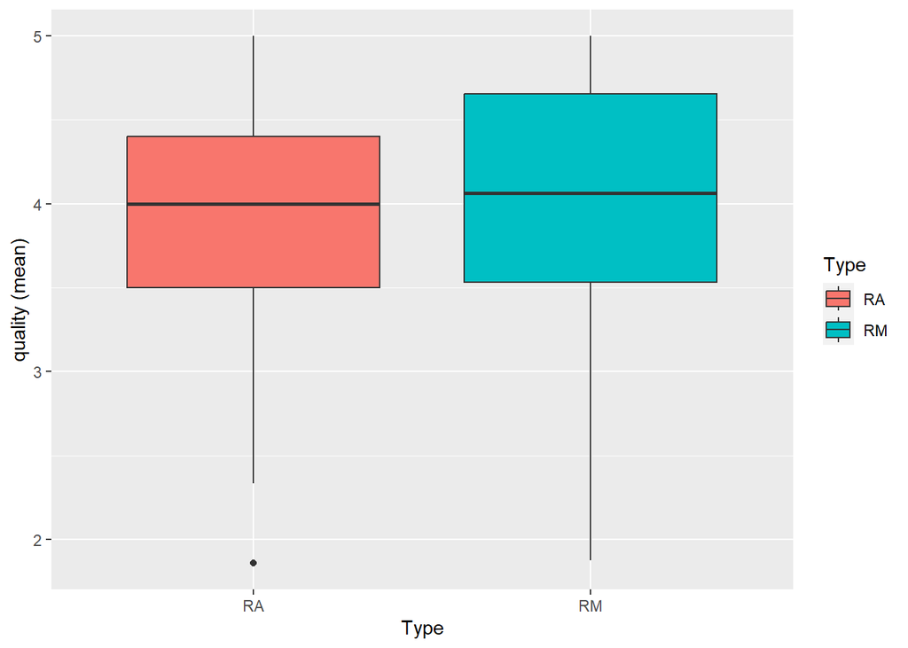

```r
ggplot(outcome, aes(x = Type, y = quality, fill = Type)) +
  geom_boxplot()+
  ylab("quality (mean)")
```

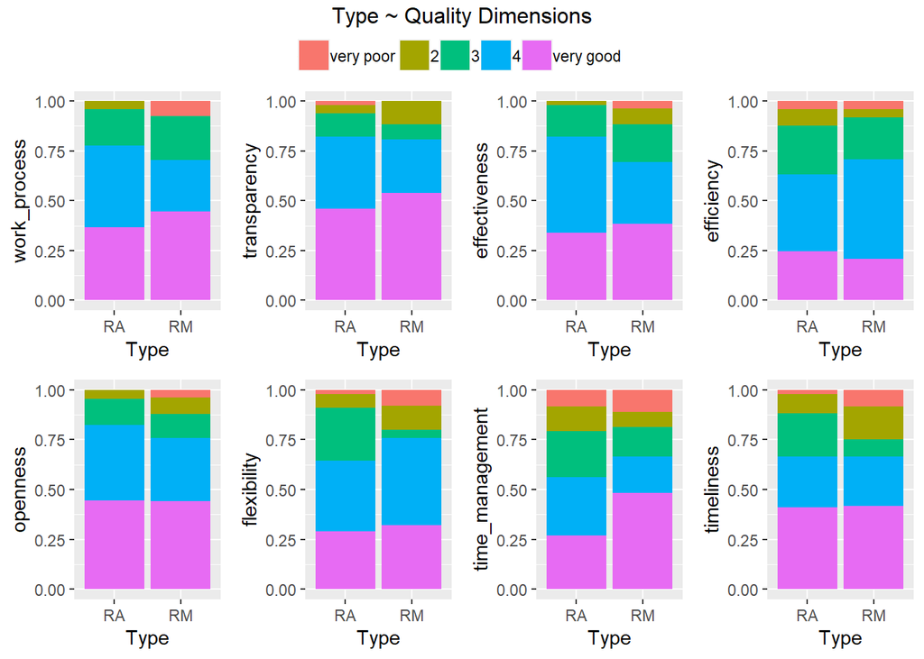

```r
plot_q1 <- ggplot(data=subset(outcome, !is.na(work_process)), aes(x = Type)) +
  geom_bar(aes(fill = work_process), position="fill")+
  ylab("work_process")+
  theme(legend.title = element_text(size = 0))

plot_q2 <- ggplot(data=subset(outcome, !is.na(transparency)), aes(x = Type)) +
  geom_bar(aes(fill = transparency), position="fill")+
  ylab("transparency")

plot_q3 <- ggplot(data=subset(outcome, !is.na(effectiveness)), aes(x = Type)) +
  geom_bar(aes(fill = effectiveness), position="fill")+
  ylab("effectiveness")

plot_q4 <- ggplot(data=subset(outcome, !is.na(efficiency)), aes(x = Type)) +
  geom_bar(aes(fill = efficiency), position="fill")+
  ylab("efficiency")

plot_q5 <- ggplot(data=subset(outcome, !is.na(openness)), aes(x = Type)) +
  geom_bar(aes(fill = openness), position="fill")+
  ylab("openness")

plot_q6 <- ggplot(data=subset(outcome, !is.na(flexibility)), aes(x = Type)) +
  geom_bar(aes(fill = flexibility), position="fill")+
  ylab("flexibility")

plot_q7 <- ggplot(data=subset(outcome, !is.na(time_management)), aes(x = Type)) +
  geom_bar(aes(fill = time_management), position="fill")+
  ylab("time_management")

plot_q8 <- ggplot(data=subset(outcome, !is.na(timeliness)), aes(x = Type)) +
  geom_bar(aes(fill = timeliness), position="fill")+
  ylab("timeliness")

plot_o2 <- ggarrange(plot_q1,plot_q2,plot_q3,plot_q4,plot_q5,plot_q6,plot_q7,plot_q8, ncol=4, nrow=2, common.legend = TRUE)

annotate_figure(plot_o2, top = text_grob("Type ~ Quality Dimensions", size = 12))
```

```r
#Kruskall-Wallis test
KWTtype <- lapply(cols, function(x)
  kruskal.test(reformulate("Type", x), data = outcome_ccccluster))

KWTtype <- lapply(KWTtype, "[", c("data.name", "p.value"))

kable(t(as.data.frame(KWTtype)))
```

| data.name | familiarity by Type |
| --- | --- |
| p.value | 0.4744797 |
| data.name.1 | vulnerability_a by Type |
| p.value.1 | 0.6515816 |
| data.name.2 | vulnerability_b by Type |
| p.value.2 | 0.7660908 |
| data.name.3 | vulnerability_c by Type |
| p.value.3 | 0.09755288 |
| data.name.4 | feeling_valued by Type |
| p.value.4 | 0.4095451 |
| data.name.5 | ability by Type |
| p.value.5 | 0.06204802 |
| data.name.6 | interest_alignment by Type |
| p.value.6 | 0.2745858 |

# Type - relationship

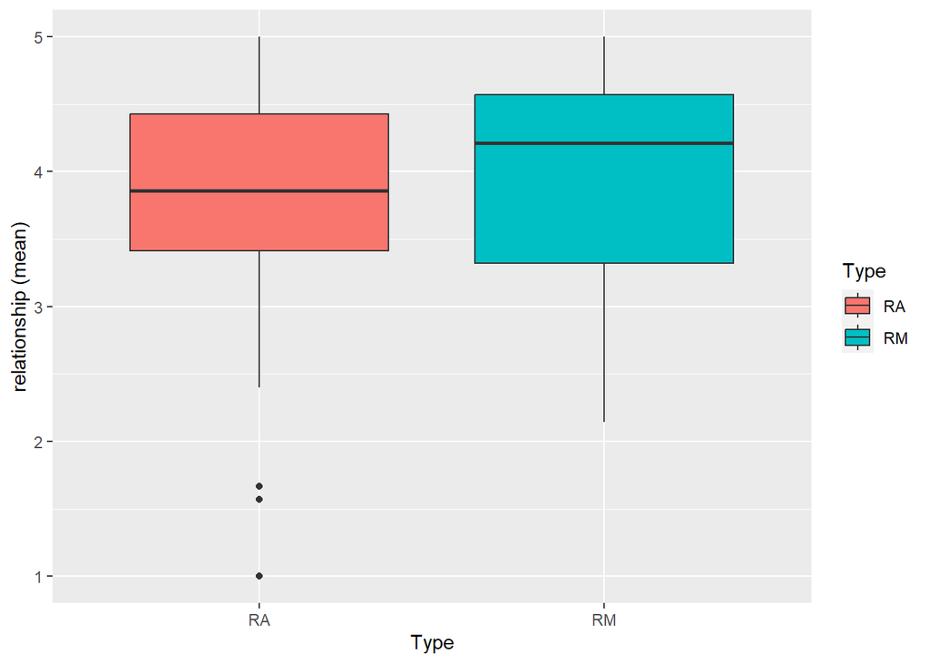

```r
ggplot(outcome, aes(x = Type, y = relationship, fill = Type)) +
  geom_boxplot()+
  ylab("relationship (mean)")
```

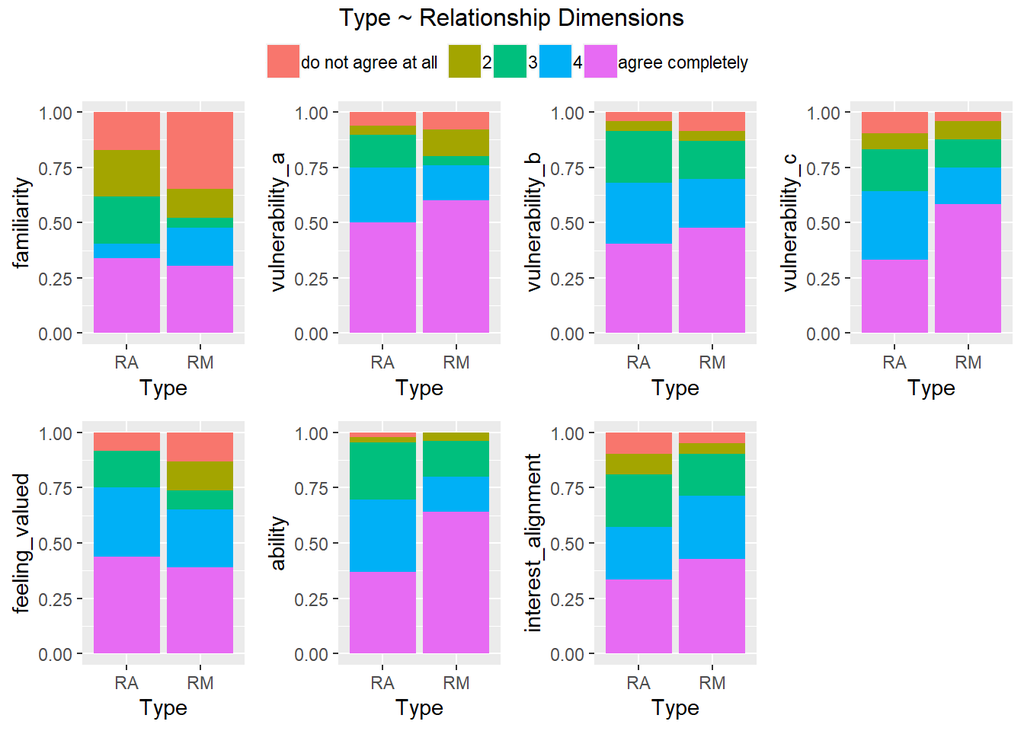

```r
plot_r1 <- ggplot(data=subset(outcome, !is.na(familiarity)), aes(x = Type)) +
  geom_bar(aes(fill = familiarity), position="fill")+
  ylab("familiarity")+
  theme(legend.title = element_text(size = 0))

plot_r2 <- ggplot(data=subset(outcome, !is.na(vulnerability_a)), aes(x = Type)) +
  geom_bar(aes(fill = vulnerability_a), position="fill")+
  ylab("vulnerability_a")

plot_r3 <- ggplot(data=subset(outcome, !is.na(vulnerability_b)), aes(x = Type)) +
  geom_bar(aes(fill = vulnerability_b), position="fill")+
  ylab("vulnerability_b")

plot_r4 <- ggplot(data=subset(outcome, !is.na(vulnerability_c)), aes(x = Type)) +
  geom_bar(aes(fill = vulnerability_c), position="fill")+
  ylab("vulnerability_c")

plot_r5 <- ggplot(data=subset(outcome, !is.na(feeling_valued)), aes(x = Type)) +
  geom_bar(aes(fill = feeling_valued), position="fill")+
  ylab("feeling_valued")

plot_r6 <- ggplot(data=subset(outcome, !is.na(ability)), aes(x = Type)) +
  geom_bar(aes(fill = ability), position="fill")+
  ylab("ability")

plot_r7 <- ggplot(data=subset(outcome, !is.na(interest_alignment)), aes(x = Type)) +
  geom_bar(aes(fill = interest_alignment), position="fill")+
  ylab("interest_alignment")

plot_qual_all <- ggarrange(plot_r1,plot_r2,plot_r3,plot_r4,plot_r5,plot_r6,plot_r7, ncol=4, nrow=2, common.legend = TRUE)

annotate_figure(plot_qual_all, top = text_grob("Type ~ Relationship Dimensions", size = 12))
```

```r
#Kruskall-Wallis test
KWTtype <- lapply(cols, function(x)
  kruskal.test(reformulate("Type", x), data = outcome_ccccluster))

KWTtype <- lapply(KWTtype, "[", c("data.name", "p.value"))

kable(t(as.data.frame(KWTtype)))
```

| data.name | familiarity by Type |
| --- | --- |
| p.value | 0.4744797 |
| data.name.1 | vulnerability_a by Type |
| p.value.1 | 0.6515816 |
| data.name.2 | vulnerability_b by Type |
| p.value.2 | 0.7660908 |
| data.name.3 | vulnerability_c by Type |
| p.value.3 | 0.09755288 |
| data.name.4 | feeling_valued by Type |
| p.value.4 | 0.4095451 |
| data.name.5 | ability by Type |
| p.value.5 | 0.06204802 |
| data.name.6 | interest_alignment by Type |
| p.value.6 | 0.2745858 |

# Frequency of communication (from 0 to 100)

```r
freq_com <- data %>%
  dplyr::select(freq = c(RALE3a_1, RMLE3a_1), Type)%>%
  mutate(freq = coalesce(freq1, freq2))%>%
  dplyr::select(-freq1, -freq2)%>%
  mutate(freq = as.numeric(freq))

sum(complete.cases(data$RALE3a_1))
```

```
## [1] 49
```

```r
sum(complete.cases(data$RMLE3a_1))
```

```
## [1] 28
```

```r
summary(as.numeric(data$RALE3a_1))
```

```
##    Min. 1st Qu.  Median    Mean 3rd Qu.    Max.    NA's
##   -1.00   10.00   30.00   40.27   71.00  100.00      37
```

```r
summary(as.numeric(data$RMLE3a_1))
```

```
##    Min. 1st Qu.  Median    Mean 3rd Qu.    Max.    NA's
##   -1.00   15.50   50.00   49.79   79.25   94.00      58
```

```r
kable(cor(outcome[c(2,3,19,20)], freq_com$freq, use = "complete.obs"), col.names = c("Pearson’s r"))
```

|  | Pearson’s r |
| --- | --- |
| experience | -0.1299265 |
| satisfaction | 0.1624081 |
| quality | 0.1453218 |
| relationship | 0.3177768 |

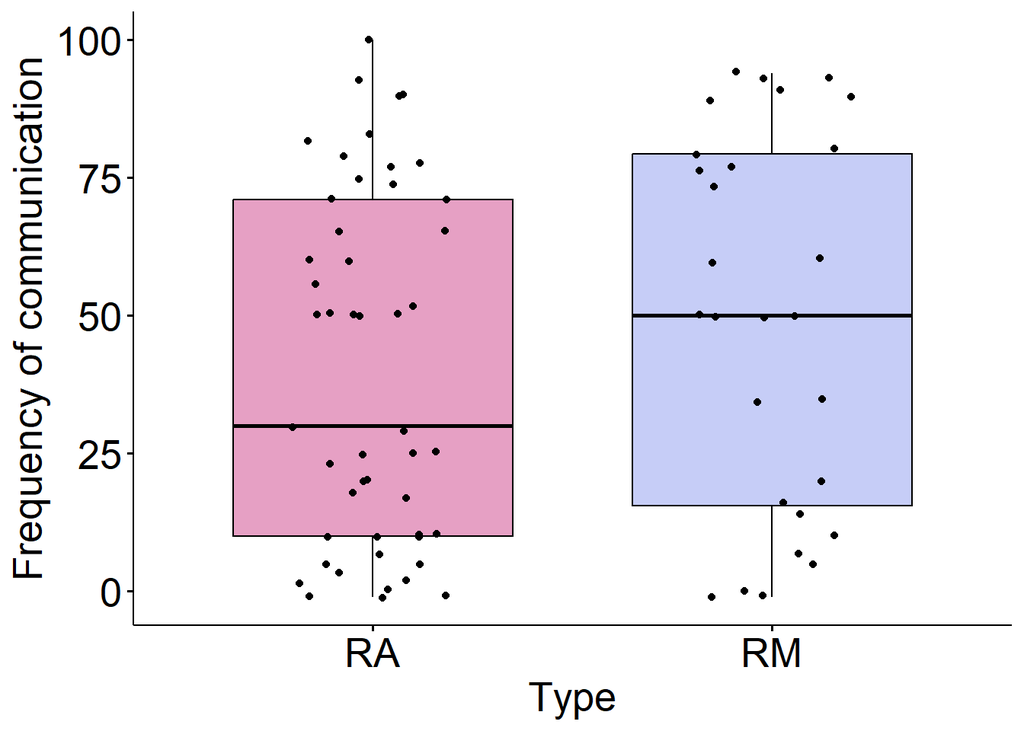

```r
ggboxplot(freq_com, x = "Type", y = "freq", add = "jitter", fill = "Type")+
  ylab("Frequency of communication") +
  scale_fill_paletteer_d("wesanderson::GrandBudapest2")+
  theme(text = element_text(size=20))+
  theme(legend.position="none")
```

```r
t.test(freq_com$freq~freq_com$Type, var.equal = TRUE, alternative = "two.sided")
```

```
##
##  Two Sample t-test
##
## data:  freq_com$freq by freq_com$Type
## t = -1.231, df = 75, p-value = 0.2222
## alternative hypothesis: true difference in means between group RA and group RM is not equal to 0
## 95 percent confidence interval:
##  -24.927712   5.886895
## sample estimates:
## mean in group RA mean in group RM
##         40.26531         49.78571
```

Reasons for Risk Assessment for Non-communication Multiple choice; further analysis of open questions needed.

```r
#"Why did you rarely communicate with risk management while working on the last risk analysis?

sum(complete.cases(data$RALE3b))
```

```
## [1] 30
```

```r
non_com <- data %>%
  dplyr::select(RALE3b)%>%
  separate_rows(RALE3b, sep = ",")

non_com <- as.data.frame(table(non_com$RALE3b))

non_com <- non_com %>% arrange(desc(Freq))

non_com$Percent=round(non_com$Freq/sum(non_com$Freq)*100, digits = 2)

kable(non_com, col.names = c("Reasons", "Frequency", "%"))
```

| Reasons | Frequency | % |
| --- | --- | --- |
| Ensuring the independence of the risk assessment. | 14 | 35.0 |
| Other (please specify): | 13 | 32.5 |
| Organizational constraints. | 7 | 17.5 |
| Hierarchical constraints. | 2 | 5.0 |
| Limited time. | 2 | 5.0 |
| I don´t know / I prefer not to say. | 1 | 2.5 |
| Risk manager unwilling to communicate. | 1 | 2.5 |

```r
#Why did you rarely communicate with risk assessment while working on the last risk analysis?
sum(complete.cases(data$RMLE3b))
```

```
## [1] 15
```

```r
non_com <- data %>%
  dplyr::select(RMLE3b)%>%
  separate_rows(RMLE3b, sep = ",")

non_com <- as.data.frame(table(non_com$RMLE3b))

non_com <- non_com %>% arrange(desc(Freq))

non_com$Percent=round(non_com$Freq/sum(non_com$Freq)*100, digits = 2)

kable(non_com, col.names = c("Reasons", "Frequency", "%"))
```

| Reasons | Frequency | % |
| --- | --- | --- |
| Ensuring the independence of the risk assessment. | 5 | 31.25 |
| Other (please specify): | 3 | 18.75 |
| Hierarchical constraints. | 2 | 12.50 |
| I don´t know / I prefer not to say. | 2 | 12.50 |
| Organizational constraints. | 2 | 12.50 |
| Limited time. | 1 | 6.25 |
| No trustful relationship with the risk manager. | 1 | 6.25 |

Reasons for Risk Management for Communication Multiple choice; further analysis of open questions needed.

```r
#"When you did communicate with risk assessment while working on the last risk analysis, what were the reasons?"

sum(complete.cases(data$RALE3c))
```

```
## [1] 39
```

```r
com <- data %>%
  dplyr::select(RALE3c)%>%
  separate_rows(RALE3c, sep = ",")

com <- as.data.frame(table(com$RALE3c))

com <- com %>% arrange(desc(Freq))

com$Percent=round(com$Freq/sum(com$Freq)*100, digits = 2)

kable(com, col.names = c("Reasons", "Frequency", "%"))
```

| Reasons | Frequency | % |
| --- | --- | --- |
| Keeping each other up to date. | 24 | 23.08 |
| Clarification of the questions in the mandate from risk assessment. | 20 | 19.23 |
| Requesting additional information on the risk assessment mandate. | 20 | 19.23 |
| Questions on the progress of the risk assessment. | 16 | 15.38 |
| Questions about the time schedule. | 14 | 13.46 |
| Giving further advice (e.g. management strategy). | 7 | 6.73 |
| Other (please specify): | 3 | 2.88 |

# Feedback on Risk Analysis

descriptive results + correlation with set of outcome variables

```r
feedback <- data %>%
  dplyr::select(ID, Type, Y_N = c(RALR6a,RMLP4a), usefulness = c(RALR6b_1,RMLP4b_1), desired_feedback = RALR7)%>%
  mutate(Y_N = coalesce(Y_N1, Y_N2))%>%
  dplyr::select(-Y_N1, -Y_N2)%>%
  mutate(usefulness = coalesce(usefulness1, usefulness2))%>%
  dplyr::select(-usefulness1, -usefulness2)%>%
  mutate(usefulness = gsub("[^0-9.-]", "", usefulness))

#RA: Did you receive any feedback on your last risk assessment from risk management?
#RM: Did you receive any feedback on the comprehensibility or any ambiguities of your last risk assessment mandate from risk assessment?
kable(table(feedback$Type, feedback$Y_N))
```

|  | I don´t know / I prefer not to say. | No | Yes |
| --- | --- | --- | --- |
| RA | 1 | 23 | 30 |
| RM | 2 | 16 | 13 |

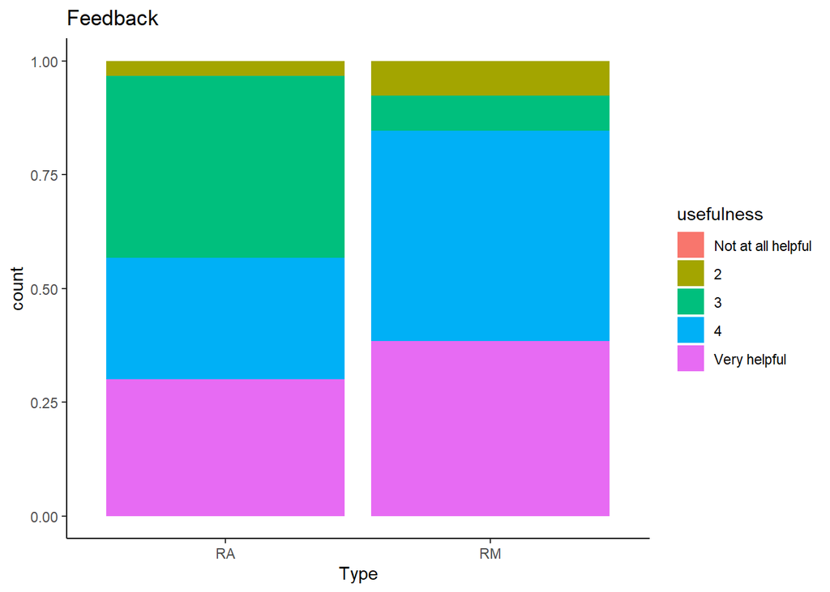

```r
#RA: How useful was the feedback for preparation of future risk assessments?
#RM: How useful was the feedback for preparation of future risk assessment mandates?
feedback$usefulness <- factor(feedback$usefulness,
    levels=1:5,
    labels=c('Not at all helpful','2','3','4','Very helpful'))

usefulness <- feedback%>%
  dplyr::select(Type, usefulness)%>%
  gather(key='Type', value='usefulness')%>%
  na.omit(usefulness)

ggplot(usefulness, aes(x=Type)) +
  geom_bar(aes(fill=usefulness), position="fill") +
  labs(
    title='Feedback',
    x='Type', y='count'
  ) +
  theme_classic()+
          scale_fill_discrete(drop=FALSE) +
          scale_x_discrete(drop=FALSE)
```

```r
# correlation of outcome with rated usefulness of feedback
kable(cor(outcome[c(2,3,19,20)], as.numeric(feedback$usefulness), use = "complete.obs"), col.names = c("Pearson’s r"))
```

|  | Pearson’s r |
| --- | --- |
| experience | -0.1408600 |
| satisfaction | 0.3722954 |
| quality | 0.1864064 |
| relationship | 0.3720024 |

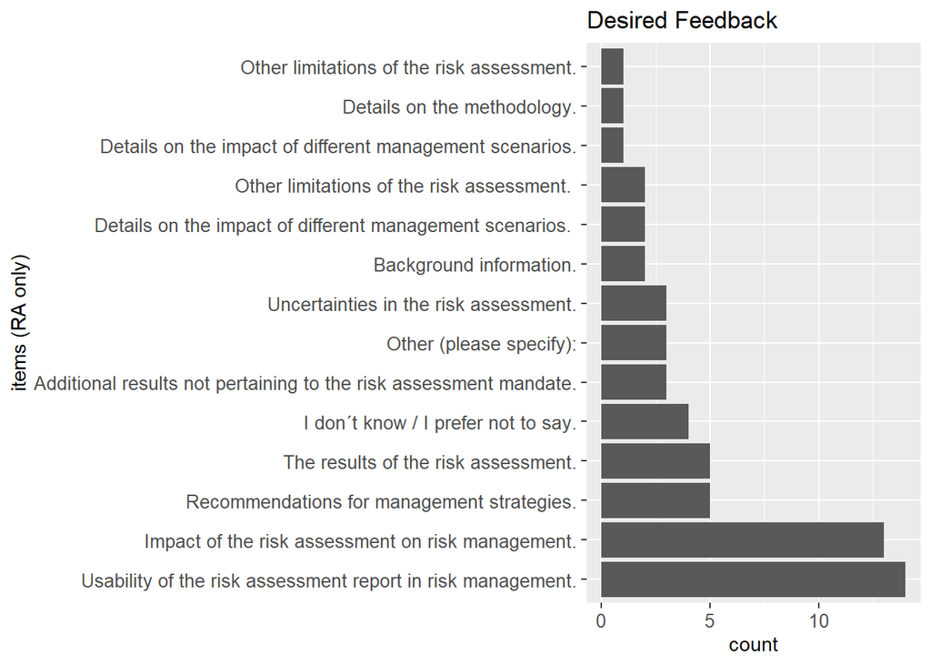

```r
feedback_sep <- feedback%>%
  separate_rows(desired_feedback, sep = ",")%>%
  na.omit(desired_feedback)

ggplot(feedback_sep, aes(x = reorder(desired_feedback,desired_feedback,
                     function(x)-length(x))))+
  geom_bar()+
  coord_flip()+
  labs(
    title='Desired Feedback',
    x='items (RA only)', y='count'
  ) +
  theme(axis.text = element_text(size = 10))
```

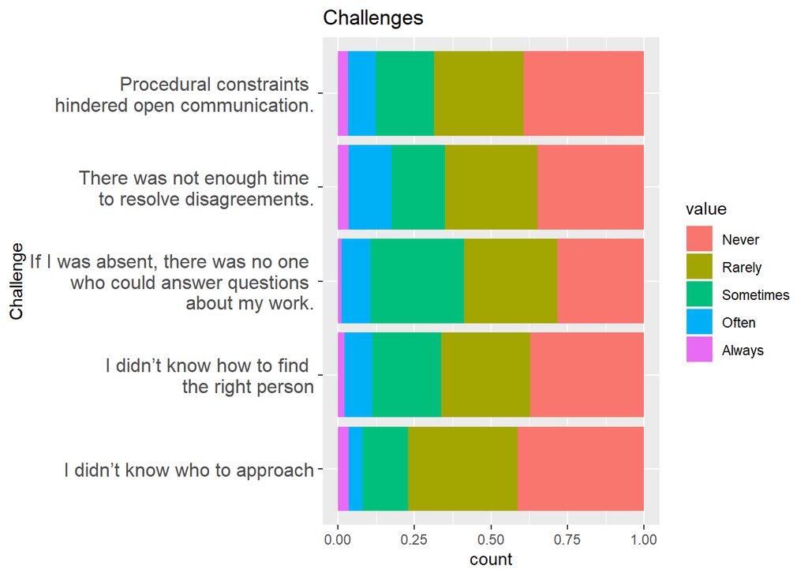

```r
all <- data2 %>%
  dplyr::select(ID, Type, challenges = c(CI1_1:CI1_5))%>%
  mutate(across(challenges1:challenges5, ~ ordered(.,
      levels = c("Never", "Rarely", "Sometimes", "Often", "Always"))))%>%
  pivot_longer(challenges1:challenges5)%>%
  na.omit(value)

ggplot(all, aes(x=name)) +
  geom_bar(aes(fill=value), position = "fill")+
  labs(
    title='Challenges',
    x='Challenge', y='count'
  ) +
  coord_flip()+
  theme(axis.text.y = element_text(size = 12))+
          scale_fill_discrete(drop=FALSE) +
          scale_x_discrete(labels=c("I didn’t know who to approach", "I didn’t know how to find \nthe right person", "If I was absent, there was no one \nwho could answer questions \nabout my work.", "There was not enough time \nto resolve disagreements.", "Procedural constraints \nhindered open communication."))
```

```r
# subject area RALG1 / RMLG1

sum(complete.cases(data$RALG1))
```

```
## [1] 55
```

```r
com <- data %>%
  dplyr::select(RALG1)%>%
  separate_rows(RALG1, sep = ",")

subj <- as.data.frame(table(trimws(com$RALG1)))
subj$Percent=round(subj$Freq/sum(subj$Freq)*100, digits = 2)

kable(subj, col.names = c("Subject Area", "Frequency", "%"))
```

| Subject Area | Frequency | % |
| --- | --- | --- |
| Biological hazards in drinking water. | 1 | 1.25 |
| Biological hazards in feed. | 3 | 3.75 |
| Biological hazards in food. | 22 | 27.50 |
| Biological hazards in water to animals. | 2 | 2.50 |
| Chemical hazards in drinking water. | 3 | 3.75 |
| Chemical hazards in feed. | 4 | 5.00 |
| Chemical hazards in food. | 31 | 38.75 |
| Chemical hazards in water to animals. | 2 | 2.50 |
| Emerging risks (related to food or feed). | 5 | 6.25 |
| Other (please specify): | 5 | 6.25 |
| Physical hazards in feed. | 1 | 1.25 |
| Physical hazards in food. | 1 | 1.25 |

Correlations

```r
length <- data %>%
  dplyr::select(length = c(RALG3, RMLG3))%>%
  mutate(length = coalesce(length1, length2))%>%
  dplyr::select(-length1, -length2)%>%
  mutate(length = factor(length,
    levels=c('Less than a month.','One to three months.','Four to six months.','Seven to twelve months.','More than a year.')))


kable(cor(outcome[c(3,19,20)], as.numeric(length$length), method = "spearman", use = "complete.obs"), col.names = c("Spearman’s r"))
```

|  | Spearman’s r |
| --- | --- |
| satisfaction | -0.2889140 |
| quality | -0.3829421 |
| relationship | -0.1944609 |

```r
cor.test(as.numeric(length$length),outcome$relationship, method = "spearman")
```

```
##
##  Spearman's rank correlation rho
##
## data:  as.numeric(length$length) and outcome$relationship
## S = 83077, p-value = 0.04837
## alternative hypothesis: true rho is not equal to 0
## sample estimates:
##        rho
## -0.2303117
```

```r
####

freq_com <- data %>%
  dplyr::select(freq = c(RALE3a_1, RMLE3a_1))%>%
  mutate(freq = coalesce(freq1, freq2))%>%
  dplyr::select(-freq1, -freq2)%>%
  mutate(freq = as.numeric(freq))


kable(cor(outcome[c(3,19,20)], freq_com$freq, method = "spearman", use = "complete.obs"), col.names = c("Spearman’s r"))
```

|  | Spearman’s r |
| --- | --- |
| satisfaction | 0.1375287 |
| quality | 0.1312554 |
| relationship | 0.2667752 |

```r
cor.test(as.numeric(length$length),outcome$relationship, method = "spearman")
```

```
##
##  Spearman's rank correlation rho
##
## data:  as.numeric(length$length) and outcome$relationship
## S = 83077, p-value = 0.04837
## alternative hypothesis: true rho is not equal to 0
## sample estimates:
##        rho
## -0.2303117
```

```r
###


kable(cor(outcome[c(3,19,20)], outcome[c(3,19,20)], method = "spearman", use = "complete.obs"))
```

|  | satisfaction | quality | relationship |
| --- | --- | --- | --- |
| satisfaction | 1.0000000 | 0.7141822 | 0.6186568 |
| quality | 0.7141822 | 1.0000000 | 0.5590524 |
| relationship | 0.6186568 | 0.5590524 | 1.0000000 |